# Disaster Relief Project: Part I

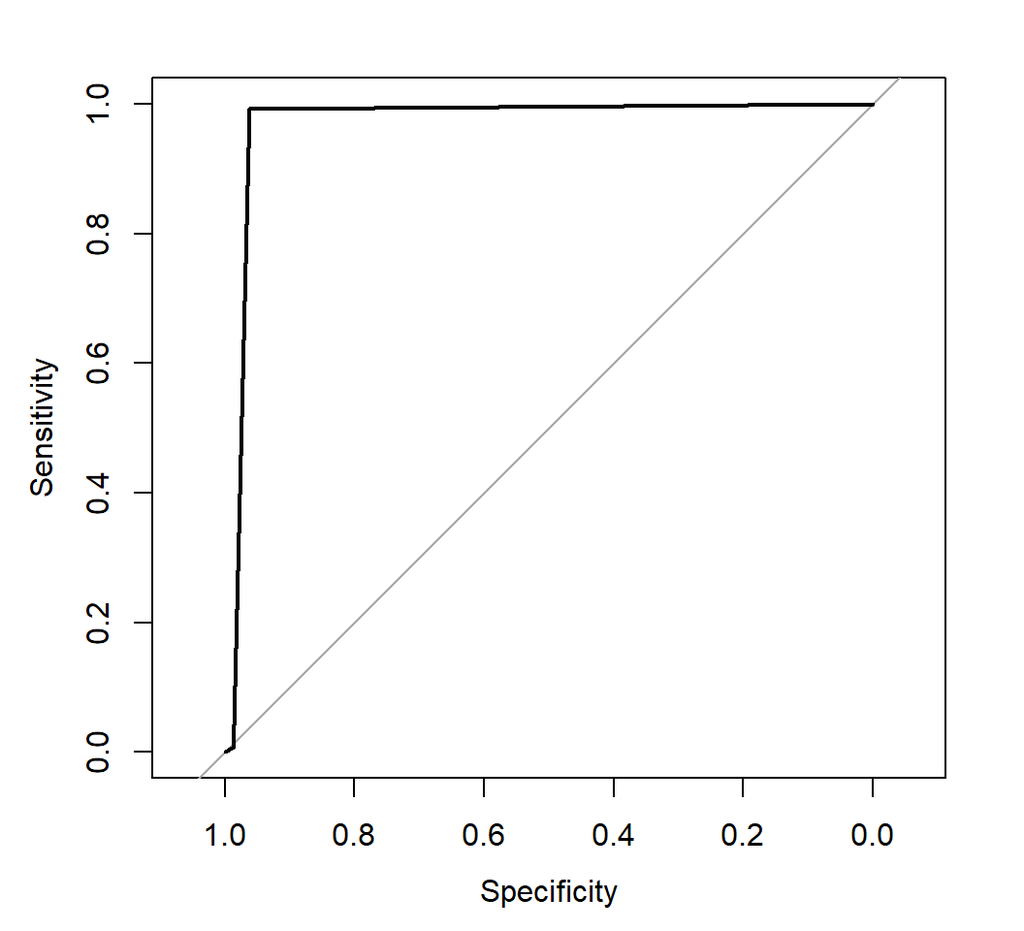

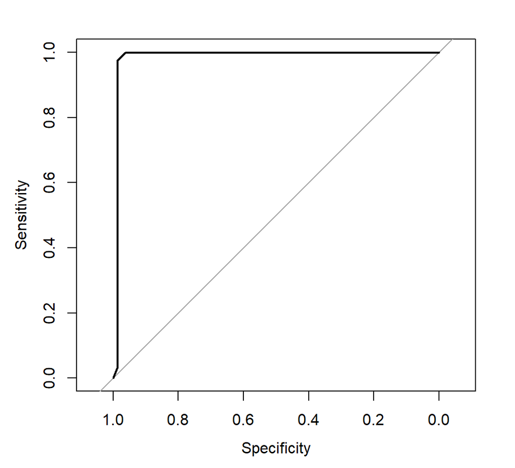

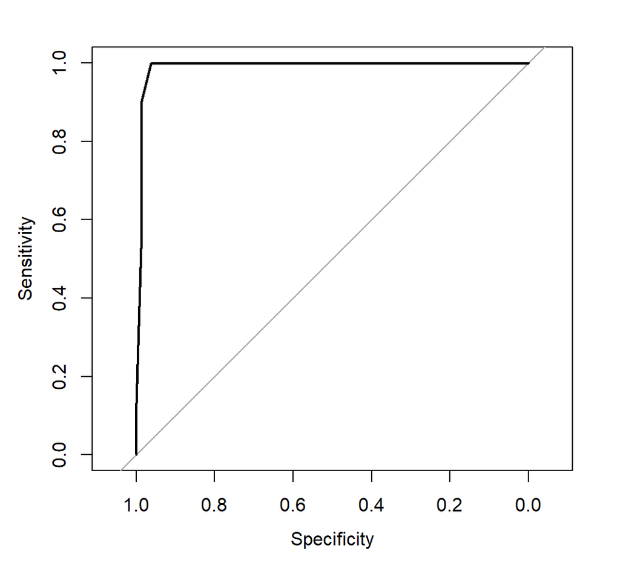

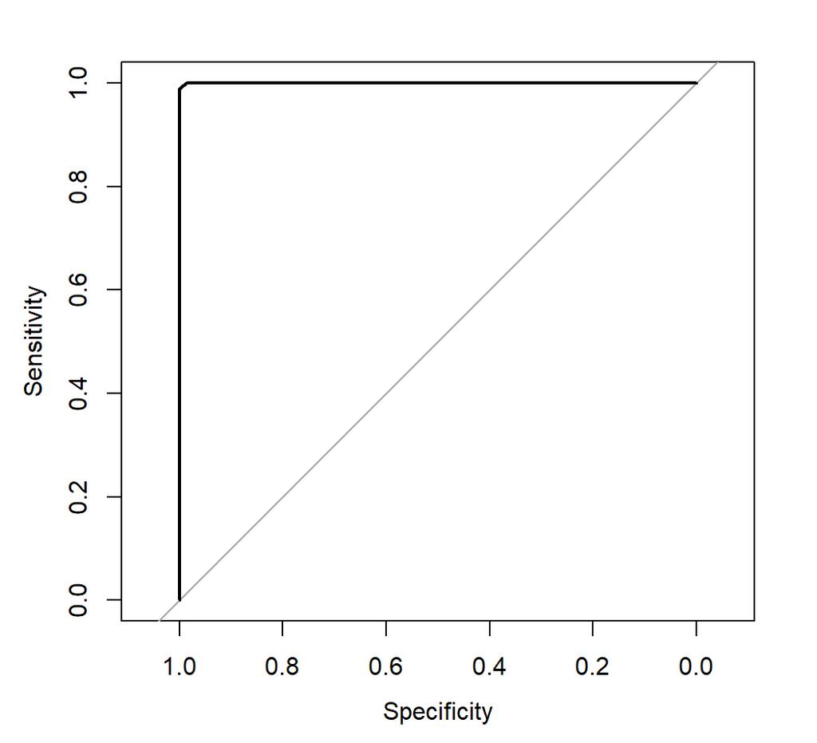

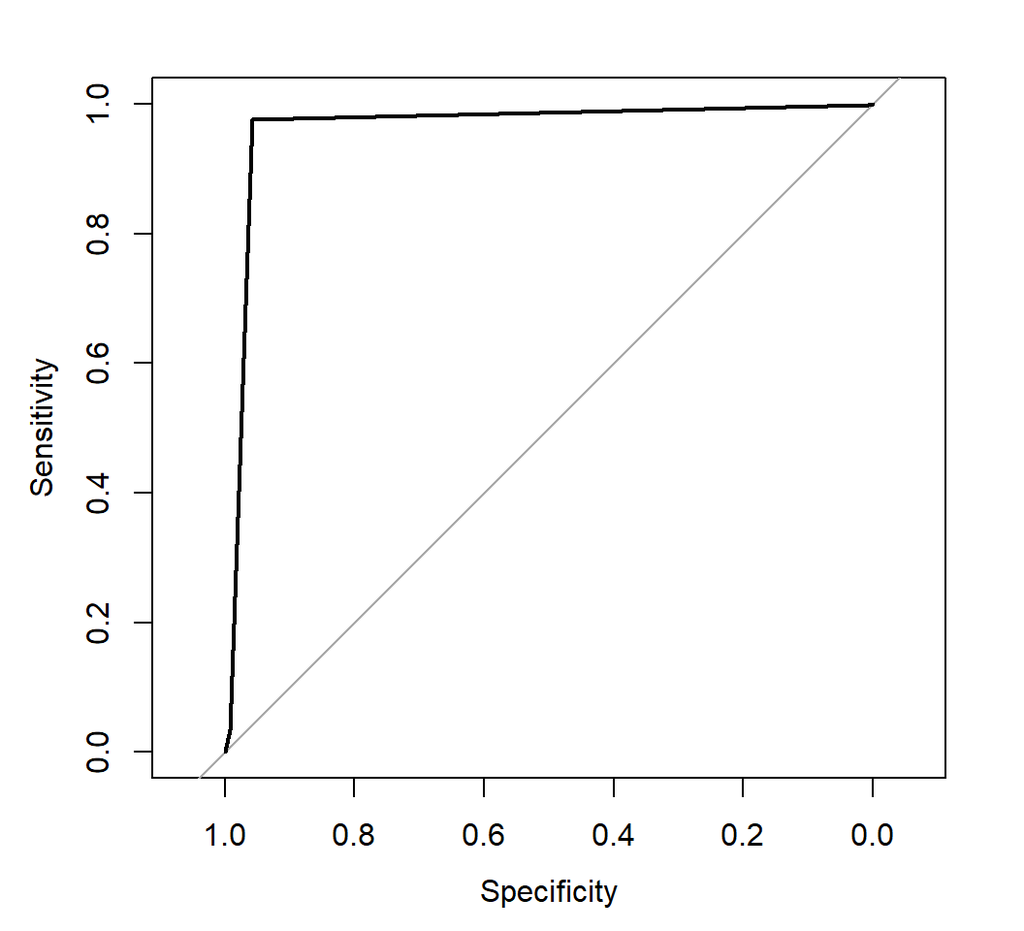

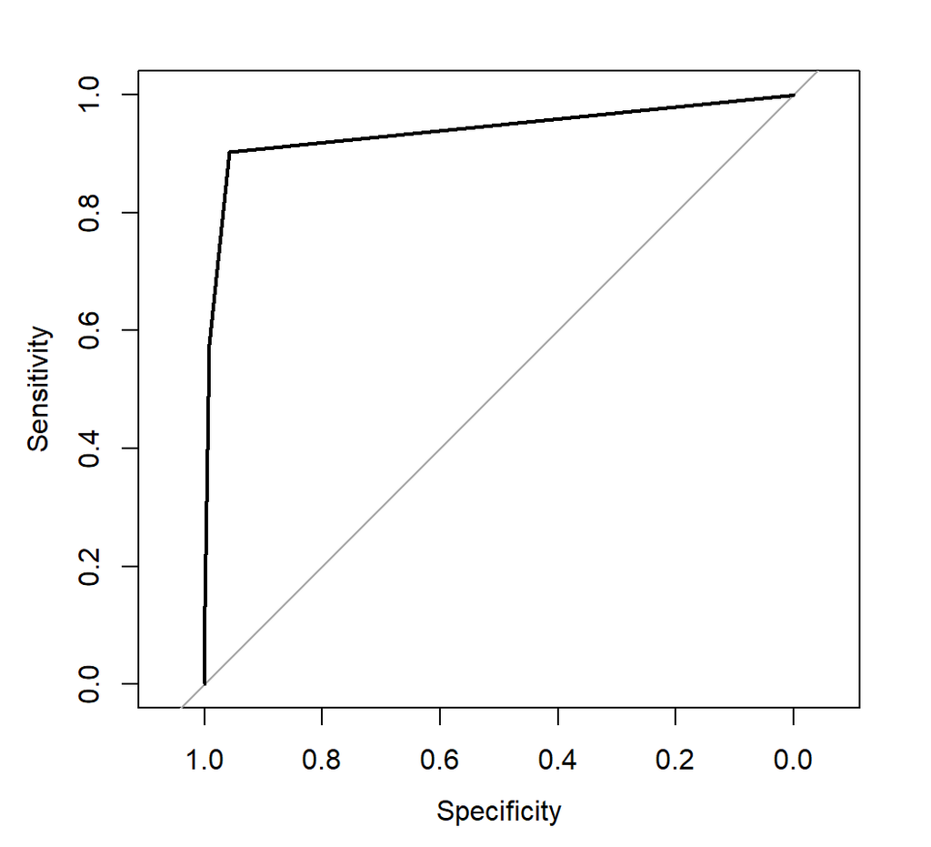

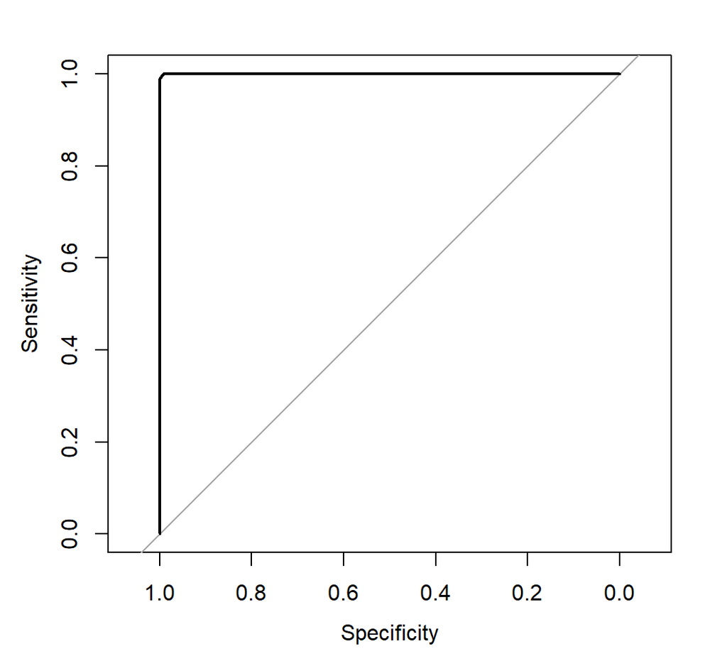

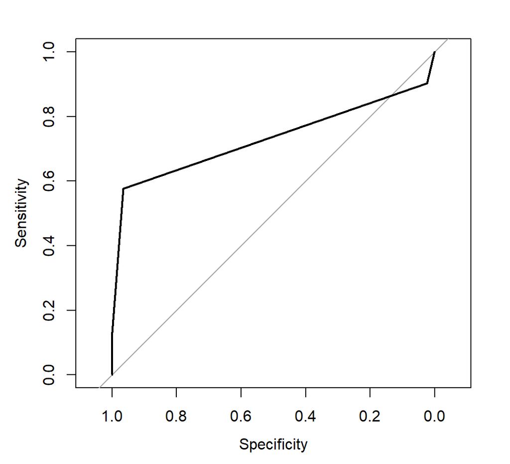

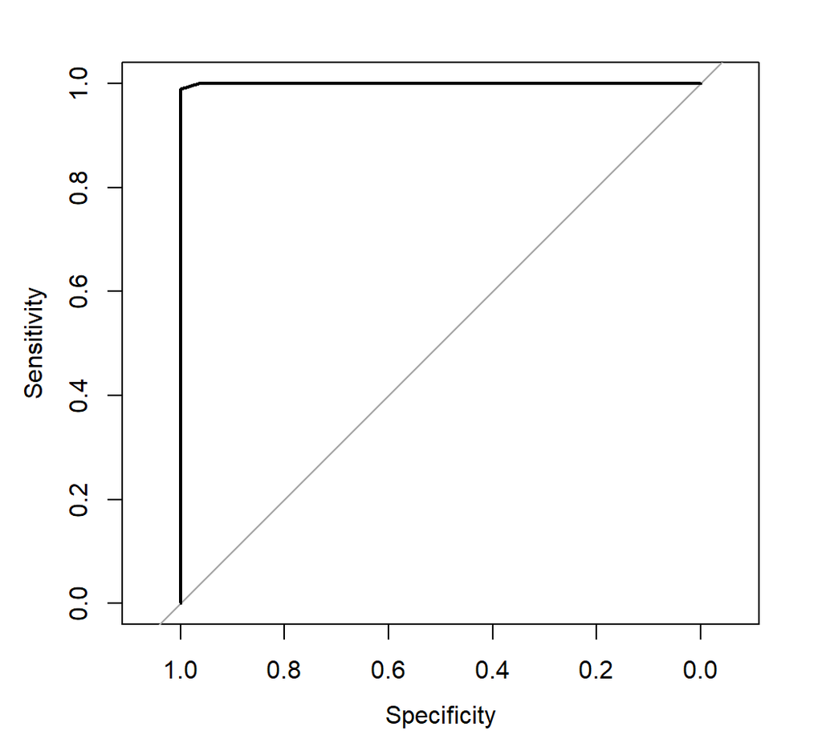

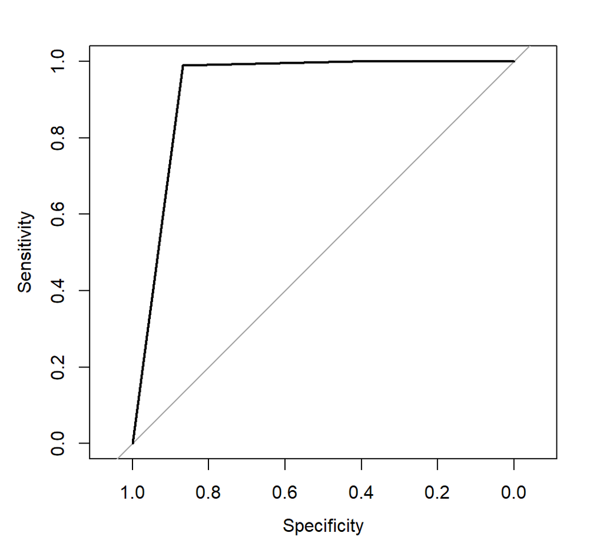

```r
#ROC/AUC
pred.knn <-predict(knn.mod, test, probability = TRUE)
pred.knn <-as.ordered(pred.knn)

roc.knn <-multiclass.roc(predictor = pred.knn, response = test$Class, plot=TRUE)
```

```r
auc.knn <-roc.knn$auc

#calculating values for CV table
#optimal k
tune.knn <-knn.mod$bestTune[,1]
#confusion matrix
tp.knn <- (c.matrixknn$table[1,1]) #true positive
fp.knn <-(sum(sum(c.matrixknn$table[1,2:5]),(sum(c.matrixknn$table[2,3:5])),sum(c.matrixknn$table[3,4:5]),sum(c.matrixknn$table[4,5]))) # false positive
fn.knn <- sum(sum(c.matrixknn$table[2,1]),(sum(c.matrixknn$table[3,1:2])),(sum(c.matrixknn$table[4,1:3])),(sum(c.matrixknn$table[5,1:4]))) #false negative
tn.knn <-sum(c.matrixknn$table[2,2],c.matrixknn$table[3,3], c.matrixknn$table[4,4], c.matrixknn$table[5,5]) # true negative
cp.knn<- tp.knn + fn.knn #condition positive
cn.knn <- fp.knn + tn.knn #condition negative
total.knn <- tp.knn+fp.knn+fn.knn+tn.knn

precision.knn <- tp.knn/(tp.knn+fp.knn)

tpr.knn <- tp.knn/cp.knn #true positive rate/sensitivity
fpr.knn <- fp.knn/cn.knn #false positive rate
accuracy.knn <- c.matrixknn$overall["Accuracy"]
```

### Tuning Parameter $k$

The optimal K for our KNN model was selected by first running 10-fold Cross-Validation on our training data. Once the cross-validation was complete, the optimal k chosen for our model was based on accuracy. In the case of our KNN model a value of *k=9* produced the highest accuracy of *0.9276967*.

## Penalized Logistic Regression (ElasticNet)

```r
#deciding which penalized log reg model to use
library(glmnet)
#prep
x.mat <- model.matrix(Class~., data=train)
y <- train$Class
#lambda grid
grid=10^seq(10,-2,length=100)

plr.spec <- trainControl(method = "cv", number = 10)

set.seed(16454)

#ridge regression
ridge<- train(Class~., data=train, method ="glmnet", tuneGrid = expand.grid(alpha=0, lambda=grid), metric = "Accuracy")
ridge.lam <- ridge$bestTune['lambda']
ridge.acc <- ridge$results[6,3]

lasso <- train(Class~., data=train, method ="glmnet", tuneGrid = expand.grid(alpha=1, lambda=grid), metric = "Accuracy")
lasso.lam <- lasso$bestTune['lambda']
lasso.acc <- lasso$results[1,3]

#elasticnet(final model)
elastic.spec <-trainControl(method = "cv", number = 10, classProbs = TRUE)
set.seed(94)
elastic.mod <- train(Class~., data=train, method = "glmnet", trControl = elastic.spec,  metric = "Accuracy")

elastic.lam <- 0.000875
elastic.acc <- elastic.mod$results[7,3]

#comparing accuracy across all three
acc.table <- data.frame(matrix(ncol = 3, nrow = 1))
colnames(acc.table) <- c("Ridge", "Lasso", "ElasticNet")
row.names(acc.table) <- ("Accuracy")
acc.table[1,1] <- ridge.acc
acc.table[1,2] <- lasso.acc
acc.table[1,3] <- elastic.acc

#show final table
print(acc.table)
```

```
#>              Ridge     Lasso ElasticNet
#> Accuracy 0.7564719 0.8469981  0.8851647
```

### Modeling best fit (ElasticNet)

```r
#predict ontest data
elastic.pred <-predict(elastic.mod, test)
#confusion matrix
c.matrixelastic <- confusionMatrix(data=elastic.pred, reference = test$Class)
c.matrixelastic
```

```
#> Confusion Matrix and Statistics
#>
#>                   Reference
#> Prediction         Blue.Tarp Rooftop Soil Various.Non.Tarp Vegetation
#>   Blue.Tarp              514      11    2                0          0
#>   Rooftop                 92    2503  350              437          3
#>   Soil                     0     441 5777              456          0
#>   Various.Non.Tarp         0      15   38              173          9
#>   Vegetation               0       0    2              357       7789
#>
#> Overall Statistics
#>
#>                Accuracy : 0.8833
#>                  95% CI : (0.8787, 0.8879)
#>     No Information Rate : 0.4112
#>     P-Value [Acc > NIR] : < 2.2e-16
#>
#>                   Kappa : 0.8282
#>
#>  Mcnemar's Test P-Value : NA
#>
#> Statistics by Class:
#>
#>                      Class: Blue.Tarp Class: Rooftop Class: Soil
#> Sensitivity                   0.84818         0.8428      0.9365
#> Specificity                   0.99929         0.9449      0.9299
#> Pos Pred Value                0.97533         0.7394      0.8656
#> Neg Pred Value                0.99501         0.9700      0.9681
#> Prevalence                    0.03195         0.1566      0.3252
#> Detection Rate                0.02710         0.1320      0.3045
#> Detection Prevalence          0.02778         0.1784      0.3518
#> Balanced Accuracy             0.92374         0.8938      0.9332
#>                      Class: Various.Non.Tarp Class: Vegetation
#> Sensitivity                          0.12157            0.9985
#> Specificity                          0.99647            0.9679
#> Pos Pred Value                       0.73617            0.9559
#> Neg Pred Value                       0.93328            0.9989
#> Prevalence                           0.07502            0.4112
#> Detection Rate                       0.00912            0.4106
#> Detection Prevalence                 0.01239            0.4295
#> Balanced Accuracy                    0.55902            0.9832
```

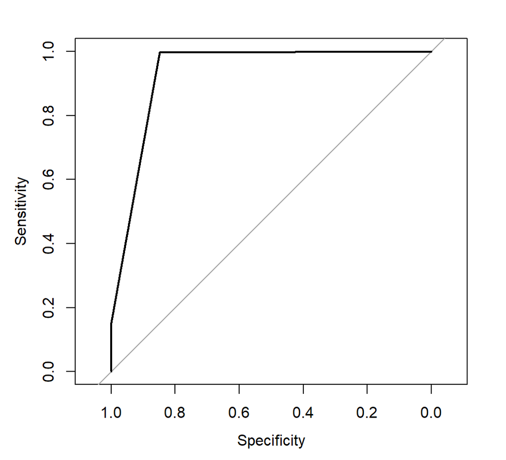

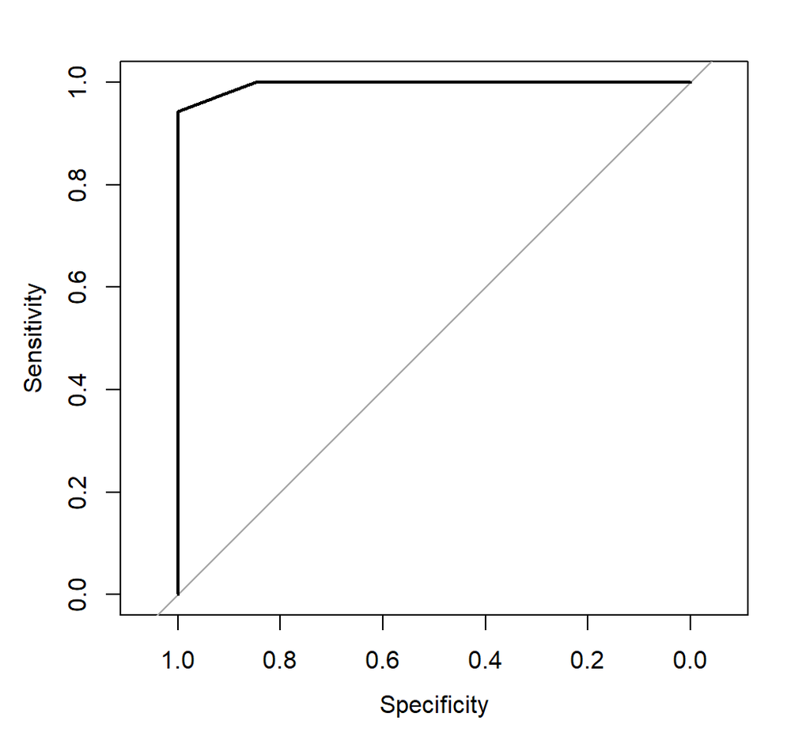

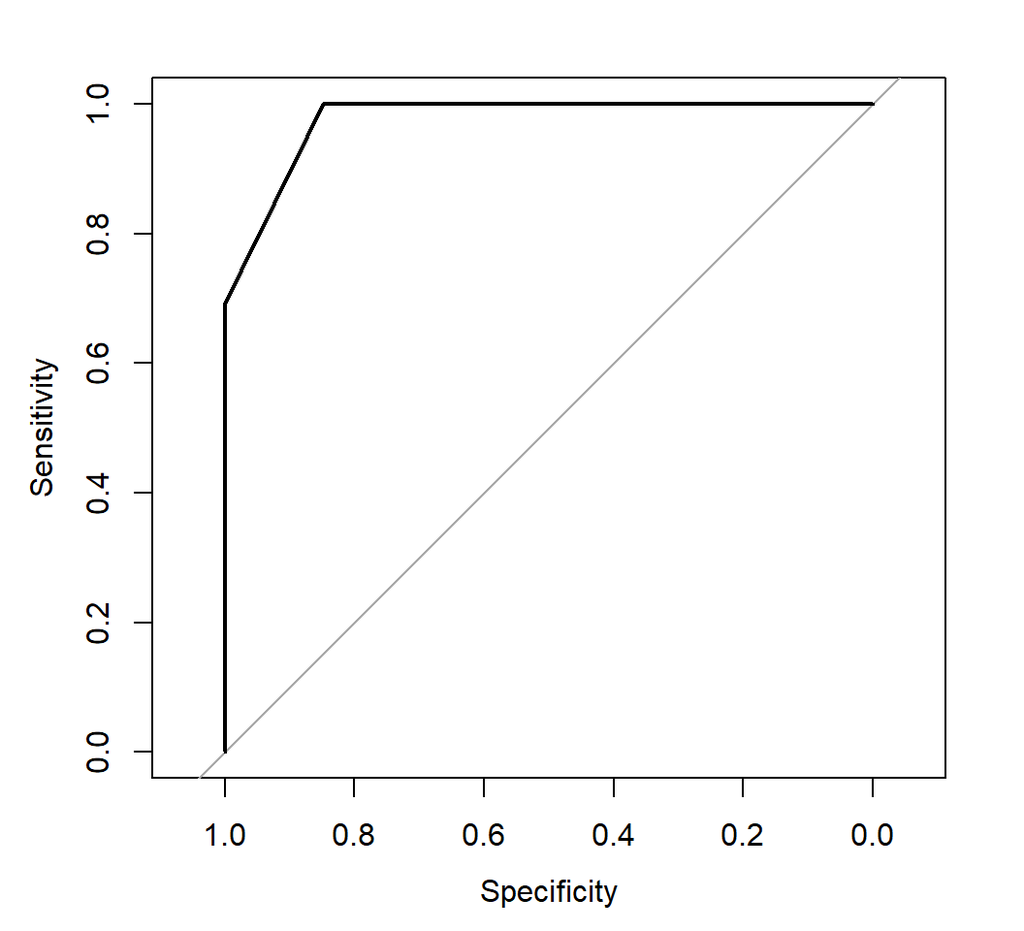

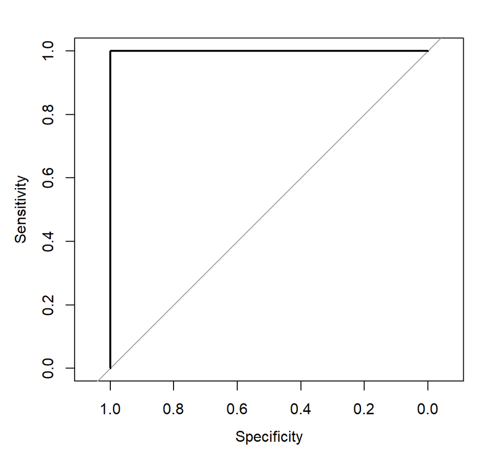

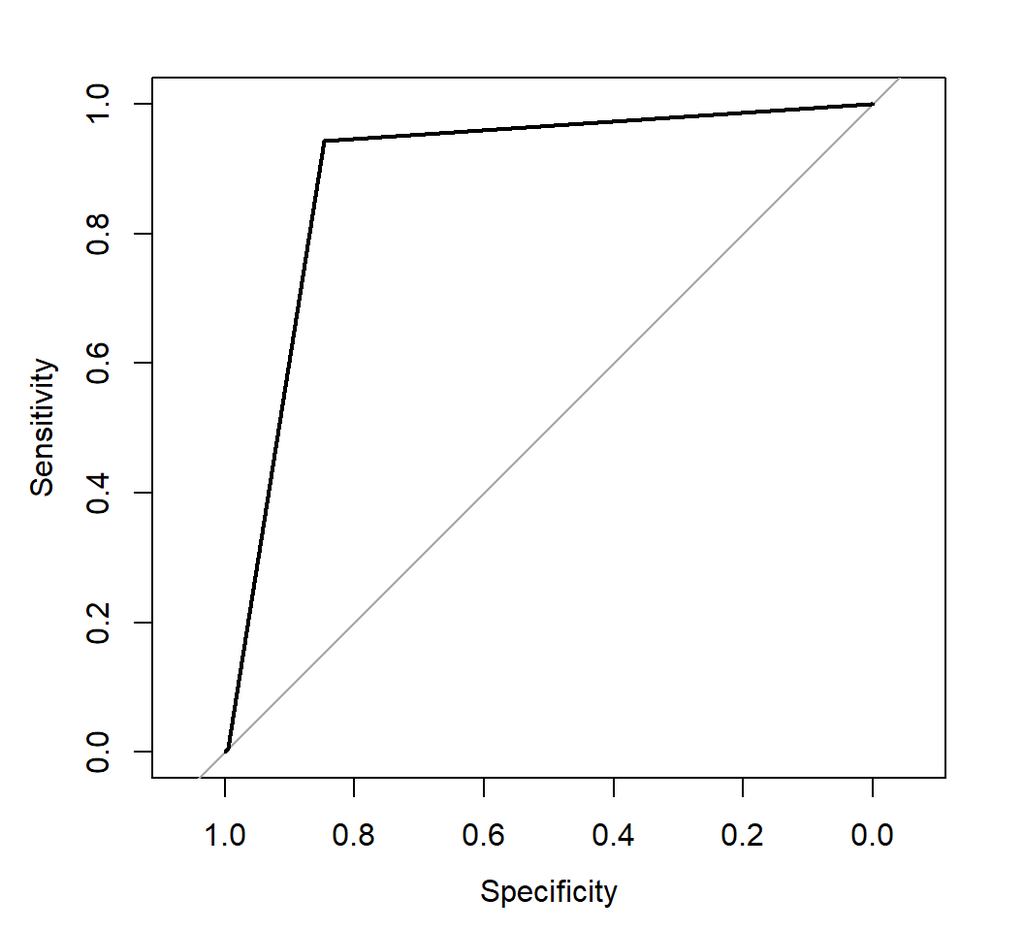

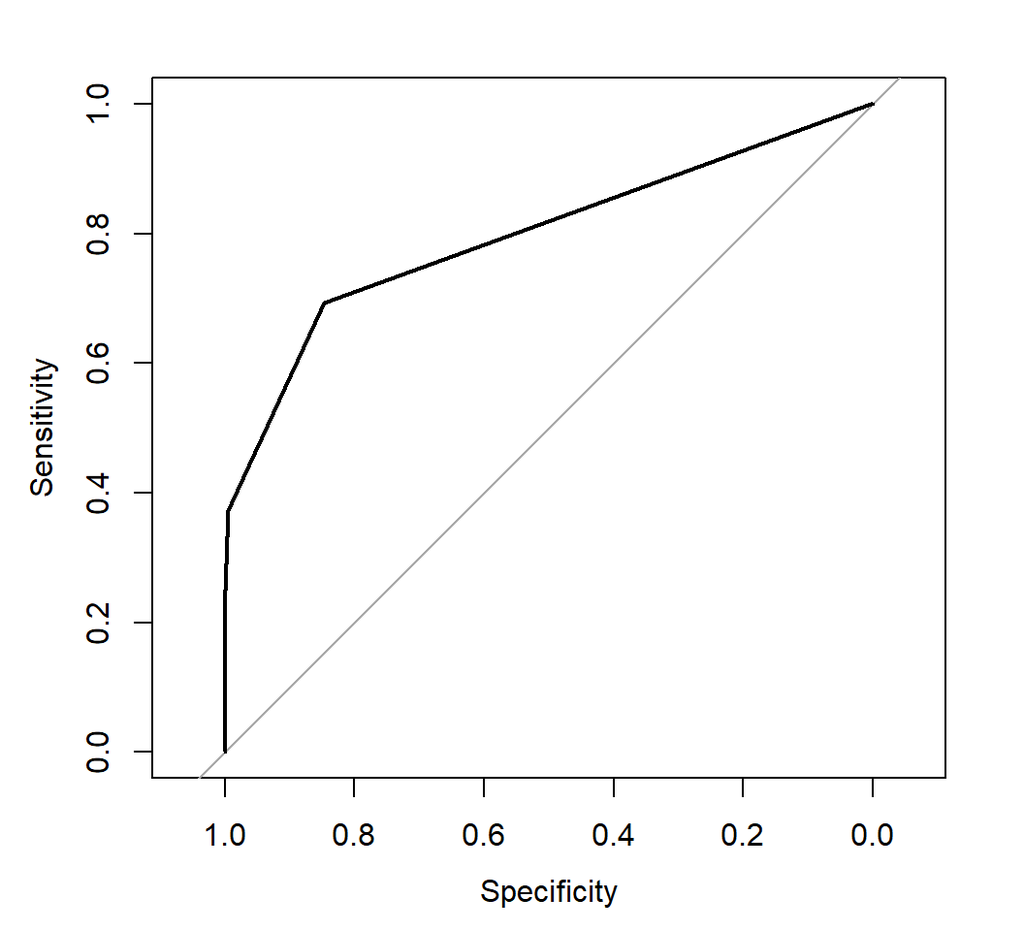

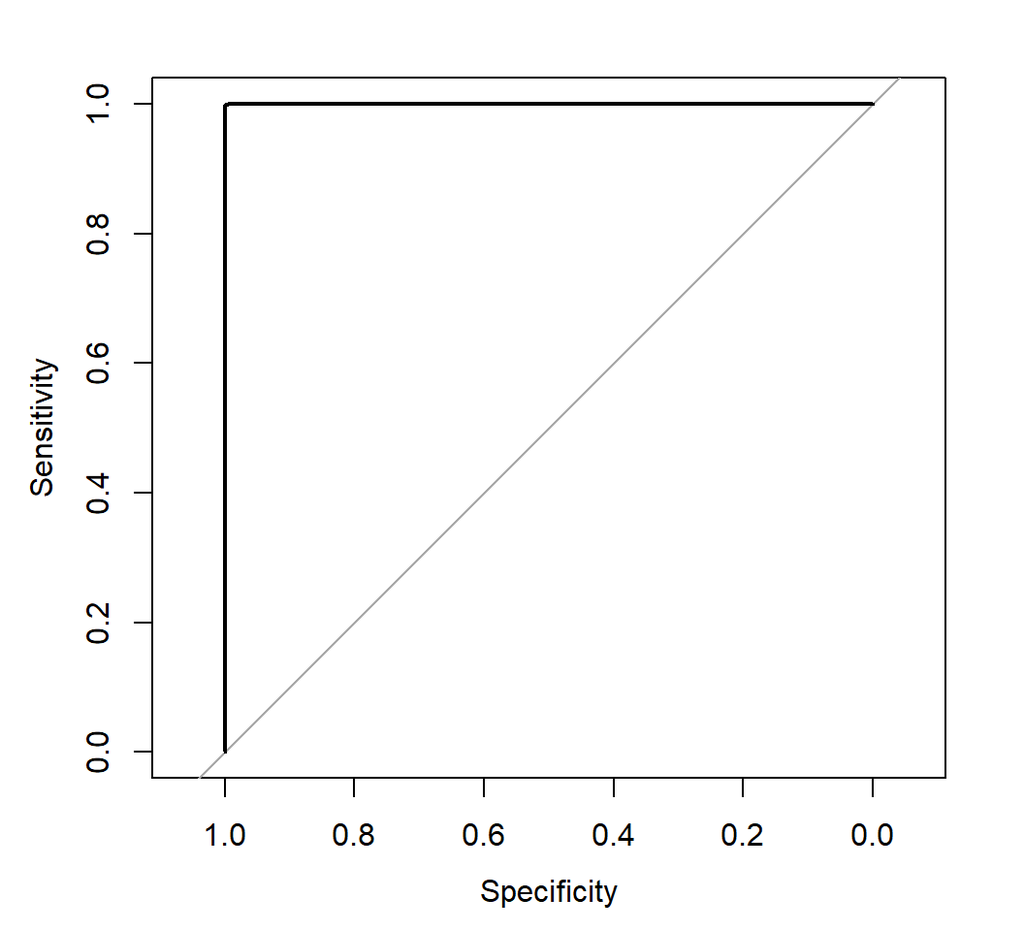

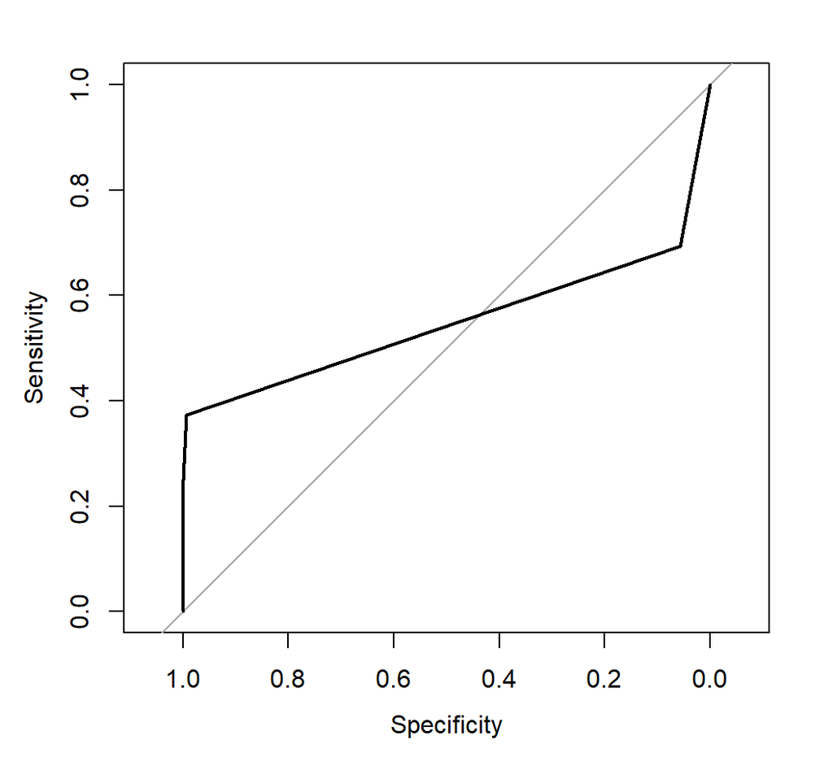

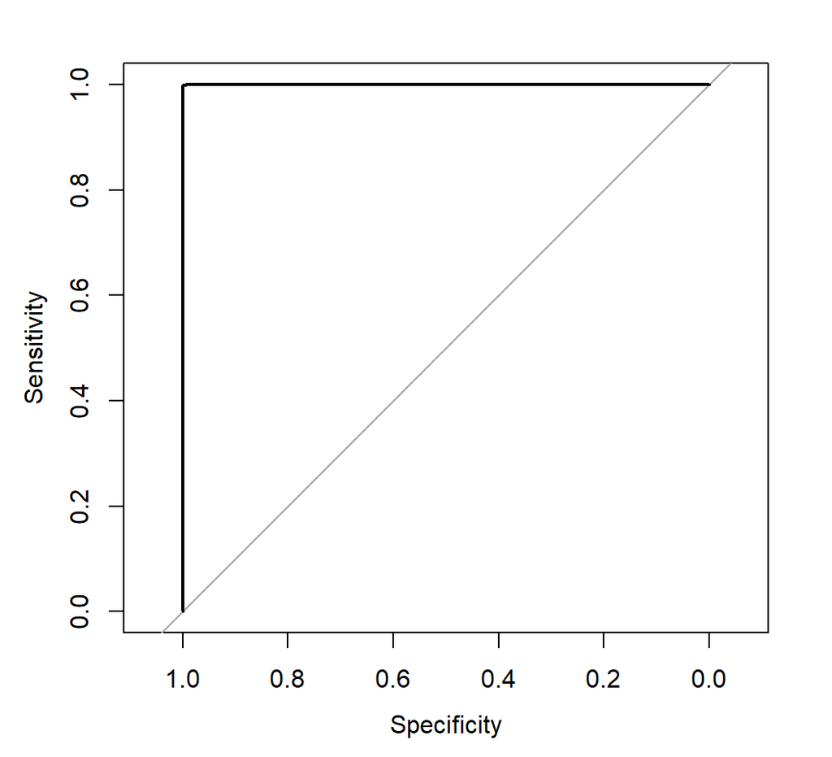

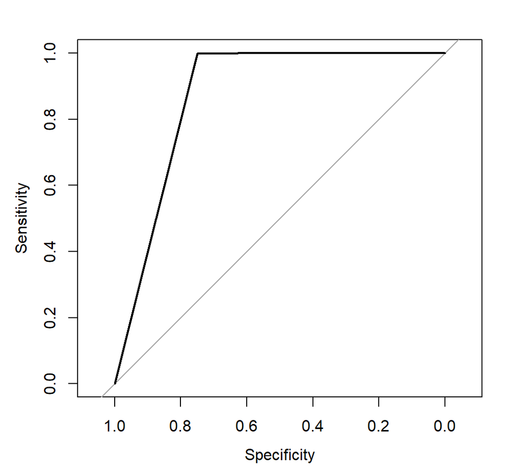

```r
#ROC/AUC
pred.elastic <-predict(elastic.mod, test, probability = TRUE)
pred.elastic <-as.ordered(pred.elastic)

roc.elastic <-multiclass.roc(predictor = pred.elastic, response = test$Class, plot=TRUE)
```

```r
auc.elastic <-roc.elastic$auc

#calculating values for CV table
#optimal lambda
tune.elastic <-elastic.mod$bestTune[1,2]
#confusion matrix
tp.elastic <- (c.matrixelastic$table[1,1]) #true positive
fp.elastic <-(sum(sum(c.matrixelastic$table[1,2:5]),(sum(c.matrixelastic$table[2,3:5])),sum(c.matrixelastic$table[3,4:5]),sum(c.matrixelastic$table[4,5]))) # false positive
fn.elastic <- sum(sum(c.matrixelastic$table[2,1]),(sum(c.matrixelastic$table[3,1:2])),(sum(c.matrixelastic$table[4,1:3])),(sum(c.matrixelastic$table[5,1:4]))) #false negative
tn.elastic <-sum(c.matrixelastic$table[2,2],c.matrixelastic$table[3,3], c.matrixelastic$table[4,4], c.matrixelastic$table[5,5]) # true negative
cp.elastic<- tp.elastic + fn.elastic #condition positive
cn.elastic <- fp.elastic + tn.elastic #condition negative
total.elastic <- tp.elastic+fp.elastic+fn.elastic+tn.elastic

precision.elastic <- tp.elastic/(tp.elastic+fp.elastic)

tpr.elastic <- tp.elastic/cp.elastic #true positive rate/sensitivity
fpr.elastic <- fp.elastic/cn.elastic #false positive rate
accuracy.elastic <- c.matrixelastic$overall["Accuracy"]
```

### Tuning Parameter $\lambda$

The optimal lambda value chosen for our penalized logistic regression model is *0.0008751504*. This was value was chosen by first completing 10-fold cross validation on Ridge Regression, Lasso Regression, and ElasticNet regression. From the three, the model with the highest accuracy(ElasticNet) was chosen to predict on our test data. The ElasticNet model with a lambda value of *0.0008751504* has an accuracy of *0.8851647*.

# Results (Cross-Validation)

```r
cv_table <- data.frame(matrix(ncol = 7, nrow = 5))
colnames(cv_table)<-c("Tuning", "AUROC", "Threshold", "Accuracy", "TPR", "FPR", "Precision")
row.names(cv_table)<- c("Log Reg", "LDA", "QDA","KNN", "PLR")

#adding in log reg values
cv_table[1,1] <- "-"
cv_table[1,2] <- auc.log
cv_table[1,3] <- threshold.log
cv_table[1,4] <- accuracy.log
cv_table[1,5] <- tpr.log
cv_table[1,6] <- fpr.log
cv_table[1,7] <- precision.log

#adding in lda values
cv_table[2,1] <- "-"
cv_table[2,2] <- auc.lda
cv_table[2,3] <- "0.5"
cv_table[2,4] <- accuracy.lda
cv_table[2,5] <- tpr.lda
cv_table[2,6] <- fpr.lda
cv_table[2,7] <- precision.lda

#adding in qda values
cv_table[3,1] <- "-"
cv_table[3,2] <- auc.qda
cv_table[3,3] <- "0.5"
cv_table[3,4] <- accuracy.qda
cv_table[3,5] <- tpr.qda
cv_table[3,6] <- fpr.qda
cv_table[3,7] <- precision.qda

#adding in KNN values
cv_table[4,1] <- tune.knn
cv_table[4,2] <- auc.knn
cv_table[4,3] <- "-"
cv_table[4,4] <- accuracy.knn
cv_table[4,5] <- tpr.knn
cv_table[4,6] <- fpr.knn
cv_table[4,7] <- precision.knn

#adding in ElasticNet values
cv_table[5,1] <- tune.elastic
cv_table[5,2] <- auc.elastic
cv_table[5,3] <- "-"
cv_table[5,4] <- accuracy.elastic
cv_table[5,5] <- tpr.elastic
cv_table[5,6] <- fpr.elastic
cv_table[5,7] <- precision.elastic

print.data.frame(cv_table)
```

```
#>                       Tuning     AUROC Threshold  Accuracy       TPR        FPR
#> Log Reg                    - 0.9459340       0.5 0.9957303 0.9991288 0.10726073
#> LDA                        - 0.8509979       0.5 0.8559755 0.2351288 0.06528454
#> QDA                        - 0.9031830       0.5 0.9003638 0.3767806 0.05778537
#> KNN                        9 0.9510827         - 0.9258791 0.5118734 0.04772319
#> PLR     0.000875150424708525 0.9019021         - 0.8833360 0.3522961 0.07241576
#>         Precision
#> Log Reg 0.9964701
#> LDA     0.3135540
#> QDA     0.3426166
#> KNN     0.4061410
#> PLR     0.2884400
```

# Conclusions

### Conclusion #2

In general, I believe that three of the models trained and tested on our data are well performing models. These models are Logistic Regression, KNN, and QDA. I believe that LDA and Penalized Logistic Regression can be removed from further consideration.The lowest accuracy model is Liner Discriminant Analysis (LDA) with an accuracy value of 0.8559755 the second lowest accuracy model is Penalized Logistic Regression(PLR) with an accuracy value of 0.8833360. Linear Discriminant Analysis and Penalized Logistic Regression are the “worst” performing models but there are additional factors to consider. I believe that Penalized Logistic Regression is not appropriate for our specific data set. PLR is designed to penalize unnecessary predictors and in our data set there are no unnecessary predictors. Our data relies on RGB values to determine the color of a pixel and thus none can be removed or should be considered for removal/penalty. As for Linear Discriminant Analysis(LDA), our data, from EDA does not appear to have a perfectly linear relationship with the response. Scatterplots of each predictor against the response show a possible linear relationship, however, the values fan out which I believe is better modeled by Quadratic Linear Analysis (QDA) in order to avoid adding any unecessary bias to the model. The flexibility introduced through using a QDA model is better suited for our data which is not overly non-linear but not perfectly linear either. QDA should fit the data appropiately without compromising the model’s bias/variance. This is shown through the accuracy difference between LDA and QDA where QDA performs better by ~0.05 in terms of accuracy. Lastly, when comparing LDA and QDA we must consider the size of our data set. Since we have over 60k observations and a small number of predictors, QDA is an appropiate choice since there are plenty of observations to train on and few predictors.

### Conclusion #3

While I am a bit skeptical on the accuracy of the logistic regression model, I believe it could be very good in future model training. In the next part of this project I would spend more time either 1)performing a multi-class/multinomial regression on the data set or 2) Performing regression on the other four models using a true binary response such as the one I used for the logistic regression.

### Conclusion #4

I believe that the use of this model and work, for disaster relief, would in fact save lives. I do not believe that it could function on its own as the only tool for relief efforts. This modeling would work best in conjunction with other tools that help model and predict the the best approachs on allocating resources and aid to displaced Haitians. The models presented above provide information as to what type of image is being shown but nothing else. This is not to discount the power of that knowledge as the provided information is very powerful. Ideally you want to combine this model with other models and tools that consider: | - How far is a blue tarp from a(n) aid station(s)? | - Is there a concentration of blue tarps in a certain radius and if so how many? | - What type of navigable paths are there to the tarp location? i.e. land, water, etc | - Are there signs that a blue tarp has someone residing under it or was it left behind/abandoned?

The model created in this project would provide an important basis for more advanced tools that would increase the efficiency and efficacy of any aid being provided to displaced Haitians. Additionally, the implementation of more specified tools would inform aid organizations on how to properly allocate their resources as well as when and how to collaborate with other aid groups, if needed. Looking beyond the scope of this project, any future disasters with similar conditions would benefit greatly from the groundwork provided by the models used in Haiti. As the rate of disasters increase (whether from natural disasters/climate change) many developing countries will benefit from data science models that facilitate rescue and aid efforts.